# Visualize Data

## Visualize with ggplot2

ggplot2 is a package for visualizing data in R. It’s a “grammar of graphics”. With ggplot2, one can create all manner of visualizations. We can also explore gganimate, a package for bringing a visual to life.

The Grammar of Graphics offers up *three* key elements when creating a visualization: * data, or the dataset to be used in the visualization * geom, or what type of visualization will be created * aes, or the details of mapping the geom to the data, plus other aesthetics

The structure:

ggplot( *data to be used* ) + *geom to be used* ( mapping = *aes( like what is x, y, etc)* )

### Let’s practice with some Trees data.

Reading in the Trees dataset from Edmonton’s Open Data site

```r
trees_url <- "https://data.edmonton.ca/resource/93cp-z7sw.json?$limit=100000"  ## Just 100,000 records to make things a little faster
trees <- read.socrata(trees_url) %>% mutate(condition_percent = as.numeric(condition_percent),
                                            diameter_breast_height = as.numeric(diameter_breast_height))
head(trees)
```

```
##   condition_percent count diameter_breast_height    genus     id
## 1                70     1                     28    Ulmus 375049
## 2                70     1                     20    Picea 205006
## 3                70     1                     65    Ulmus 375139
## 4                70     1                     14    Picea 185529
## 5                70     1                     16 Fraxinus 221284
## 6                70     1                     43    Ulmus 456700
##           latitude location.type location.coordinates location_type
## 1 53.5052770229317         Point -113.52016, 53.50528     Boulevard
## 2 53.5154149719397         Point -113.65039, 53.51541          Park
## 3 53.5343400724522         Point -113.58515, 53.53434     Boulevard
## 4 53.5101129159663         Point -113.49453, 53.51011        Buffer
## 5 53.5520936650622         Point -113.57173, 53.55209          Park
## 6 53.5540248112553         Point -113.53374, 53.55402     Boulevard
##           longitude  neighbourhood_name owner planted_date
## 1 -113.520160633526           Parkallen Parks   1990-01-01
## 2   -113.6503906478          Aldergrove Parks   1990-01-01
## 3 -113.585151851142   West Jasper Place Parks   1990-01-01
## 4 -113.494526442645 Strathcona Junction Parks   1990-01-01
## 5 -113.571733524375             McQueen Parks   1990-01-01
## 6 -113.533739026078           Westmount Parks   1990-01-01
##            species     species_2      species_botanical cultivar
## 1    Elm, American     americana        Ulmus americana     <NA>
## 2 Spruce, Colorado       pungens          Picea pungens     Blue
## 3    Elm, American     americana        Ulmus americana     <NA>
## 4 Spruce, Colorado       pungens          Picea pungens     Blue
## 5       Ash, Green pennsylvanica Fraxinus pennsylvanica  Patmore
## 6    Elm, American     americana        Ulmus americana     <NA>
```

### Here’s an Example: Scatterplot

The *data* is trees. The *geom* is geom_point, for a scatterplot. The *aes* is what columns we assign to x and y.

Run the Code chunk below to see the chart.

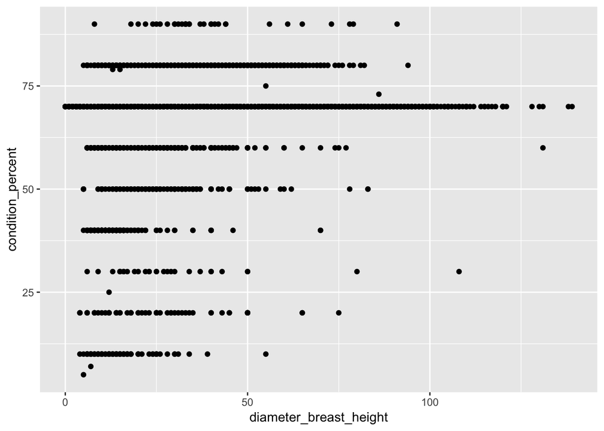

```r
ggplot(trees) +
  geom_point(mapping = aes(x = diameter_breast_height, y = condition_percent))
```

### Tree Size and Condition Percent by Genus

Here, we will use three additional arguments with our geom: *color* to visually distinguish based on another attribute in the data *alpha* to control transparency of the points *position* to modify how the points are plotted (right on top of each other? jittered a little?)

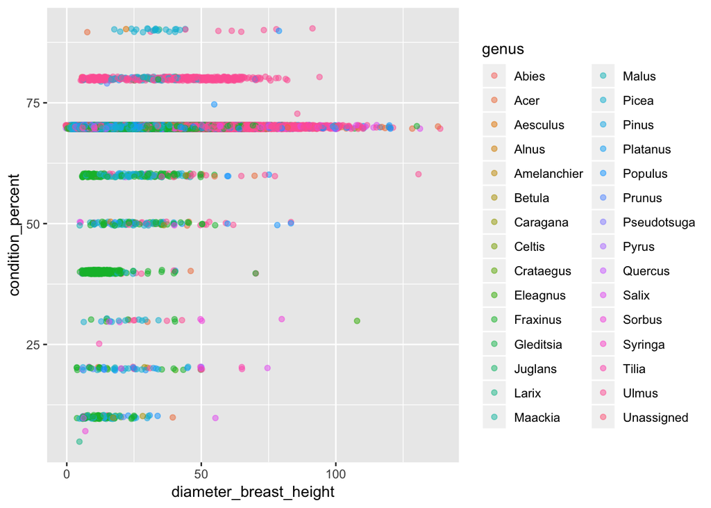

```r
ggplot(trees) +
  geom_point(mapping = aes(x = diameter_breast_height, y = condition_percent, color = genus), alpha = 0.5, position = "jitter")
```

### Try it Yourself!

In the code chunk below, create the same chart but with colors representing ‘location_type’. Some structure has been provided to get you started, but not all: aes() and all of its arguments are missing.

Stuck? Copy everything after “mapping =” and before the last parenthesis from the example above, and change *genus* to *location_type.*

```r
ggplot(trees) +
  geom_point(mapping = )
```

## Local Area Unemployment Statistics in California

### Visualize labor force, unemployment rate for areas in California

First, let’s create some subsets of the data.

```r
edd_url <- "https://data.edd.ca.gov/Labor-Force-and-Unemployment-Rates/Local-Area-Unemployment-Statistics-LAUS-/e6gw-gvii"
laus_data <- read.socrata(edd_url)

la_county <- laus_data %>% filter(`area_name` == "Los Angeles County" & `seasonally_adjusted_y_n` == "N")

la_msa <- laus_data %>% filter(area_name == "Los Angeles County" | area_name == "Orange County" & `seasonally_adjusted_y_n` == "N")

la_csa <- laus_data %>% filter(area_name == "Los Angeles County" | area_name == "Orange County" | area_name == "Ventura County" | area_name == "Riverside County" | area_name == "San Bernardino County" & `seasonally_adjusted_y_n` == "N")

la_metro <- laus_data %>% filter(area_type == "Metropolitan Area" & area_name == "Los Angeles-Long Beach-Glendale MD" & `seasonally_adjusted_y_n` == "N")

cat("Nice! We now have some filtered views of the unemployment data.")
```

```
## Nice! We now have some filtered views of the unemployment data.
```

## Let’s take a look at Los Angeles County’s unemployment rates over time.

We will use a new geom: *geom_line*

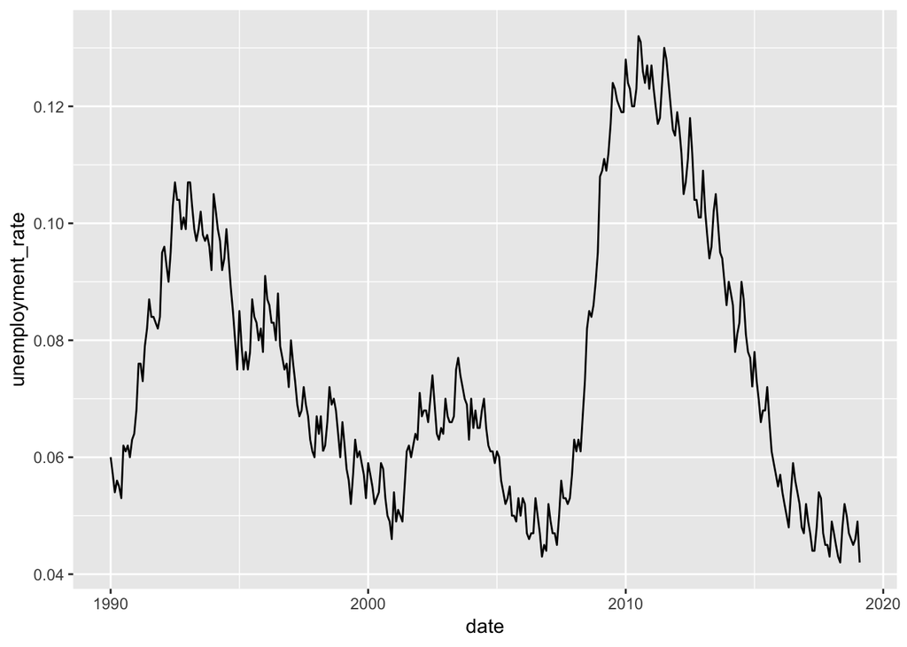

```r
ggplot(la_county) +
  geom_line(mapping = aes(x = date, y = `unemployment_rate`))
```

### Your Turn: Metropolitan Statistical Area Plot

Fill in the mapping arguments for geom_line. Recall the structure from previous examples. - x = date - y = unemployment_rate - color = area_name

```r
ggplot(la_msa) +
  geom_line(aes())
```

### CSA Plot

Let’s make sure other counties around LA don’t have the cliff that Orange County does. Run the code chunk to check.

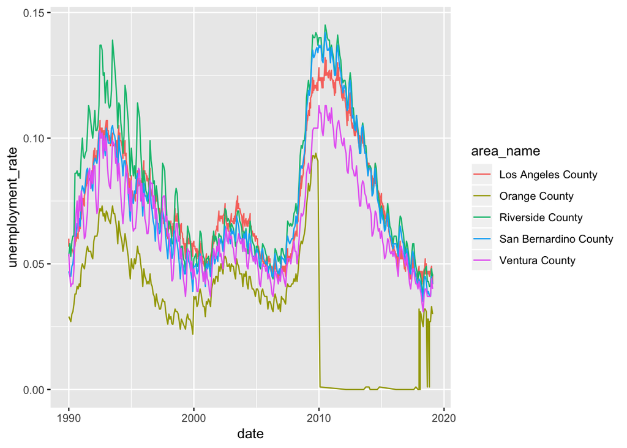

```r
ggplot(la_csa) +
  geom_line(aes(x = date, y = unemployment_rate, color = area_name))
```

## Faceting!

Faceting creates small plots of the same geom based on some discrete variable you provide.

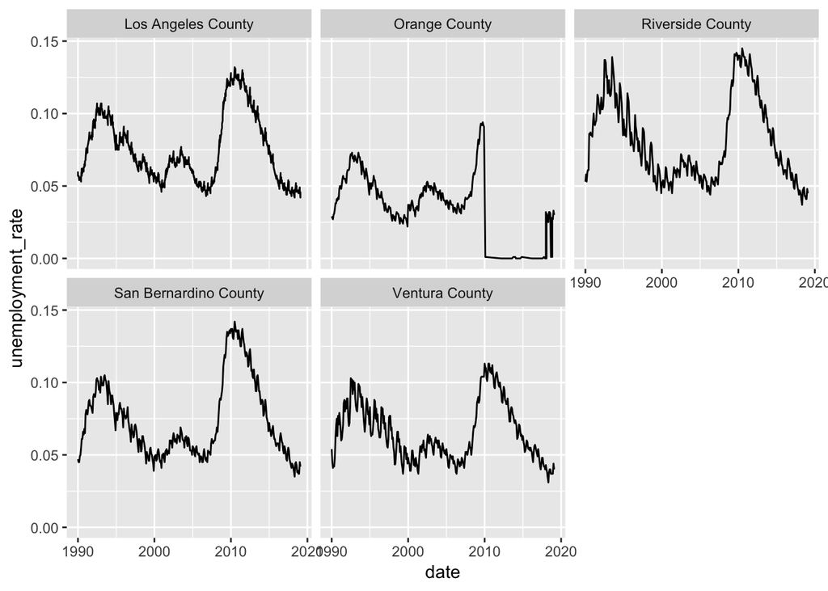

```r
ggplot(la_csa) +
  geom_line(aes(date,unemployment_rate)) +
  facet_wrap(~ area_name)
```

## ggplot and dplyr for Initial Exploration and Error Validation of Data

What’s with that cliff in 2010 for Orange County? We can spot check with further visualization and functions from the dplyr package.

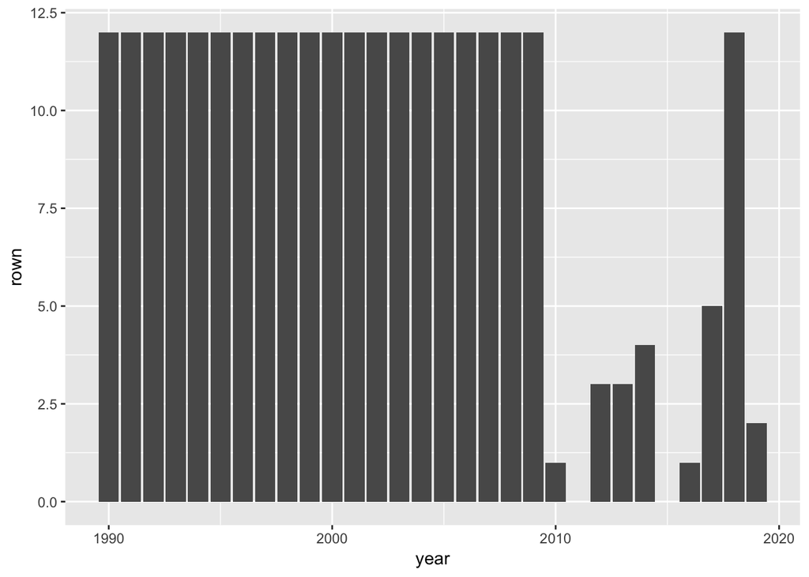

```r
the_oc <- laus_data %>% filter(area_name == "Orange County")
check_the_oc <- the_oc %>% group_by(year) %>% summarise(rown = length(unique(date)))

ggplot(check_the_oc) +
  geom_col(mapping = aes(x = year, y = rown))
```

## Further refine a visualization in all sort of ways

- Mutliple geoms
- Axis choices
- Themes
- Annotations
- And much much more!

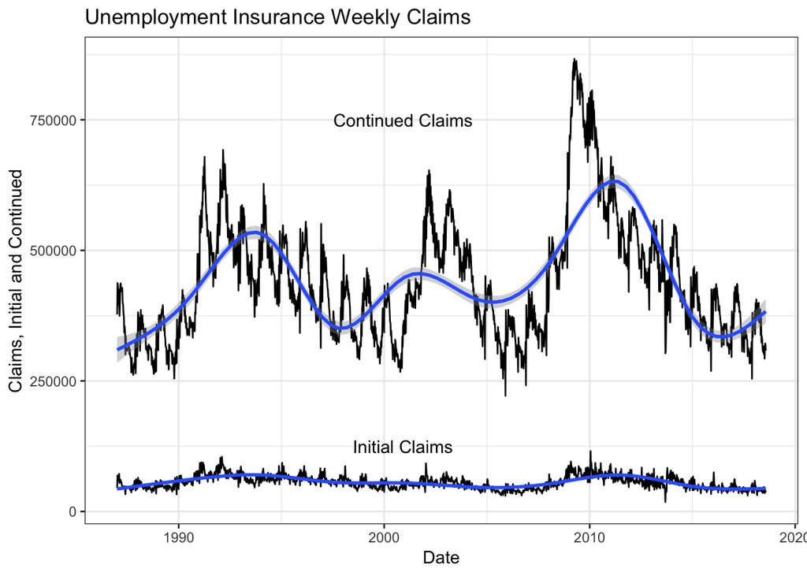

```r
uiwc_data <- read_csv("https://data.edd.ca.gov/api/views/qbrj-7mnz/rows.csv?accessType=DOWNLOAD&bom=true&format=true",
                      col_types = cols(
                        `Area Type` = "c",
                        `Area Name` = "c",
                        `Filed week ended` = col_date(format = "%m/%d/%Y"),
                        `Initial Claims` = "n",
                        `Reflecting Week Ended` = col_date(format = "%m/%d/%Y"),
                        `Continued Claims` = "n",
                        `Covered Employment` = "n",
                        `Insured Unemployment Rate` = "d"
                      ))

ggplot(uiwc_data) +
    geom_line(mapping = aes(x = `Filed week ended`, y = `Initial Claims`)) +
    geom_line(mapping = aes(x = `Filed week ended`, y = `Continued Claims`)) +
    geom_smooth(mapping = aes(x = `Filed week ended`, y = `Initial Claims`)) +
    geom_smooth(mapping = aes(x = `Filed week ended`, y = `Continued Claims`)) +
    theme_bw() +
    labs(x = "Date", y = "Claims, Initial and Continued", title = "Unemployment Insurance Weekly Claims") +
    annotate(geom = "text", x = as_date("2000-12-01"), y = 125000, label = "Initial Claims") +
    annotate(geom = "text", x = as_date("2000-12-01"), y = 750000, label = "Continued Claims")
```